# L09 Themes

Data Visualization (STAT 302)

Author

Hannah Ma

## Overview

The goal of this lab is to play around with the theme options in `ggplot2`.

## Datasets

We’ll be using the `cdc.txt` and `NU_admission_data.csv` datasets.

```r
# load package(s)
library(tidyverse)
library(patchwork)
library(showtext)

# read in the cdc dataset
cdc <- read_delim(file = "data/cdc.txt", delim = "|") %>%
  mutate(
    genhlth = factor(
      genhlth,
      levels = c("excellent", "very good", "good", "fair", "poor"),
      labels = c("Excellent", "Very Good", "Good", "Fair", "Poor")
      )
    )

# read in NU admission data
nu_data <- read.csv("data/NU_admission_data.csv") %>%
  janitor::clean_names()

# set seed
set.seed(2468)

# selecting a random subset of size 100
cdc_small <- cdc %>%
  slice_sample(n = 100)
```

## Exercise 1

Use the `cdc_small` dataset to explore several pre-set `ggthemes`. The code below constructs the familiar scatterplot of `weight` by `height` and stores it in `plot_01`. Display `plot_01` to observe the default theme. **Explore/apply, and display at least 7 other pre-set themes** from the `ggplot2` or `ggthemes` package. Don’t worry about making adjustments to the figures under the new themes. Just get a sense of what the themes are doing to the original figure `plot_01`.

There should be at least 8 plots for this task, `plot_01` is pictured below. Use `patchwork` or `cowplot` in combination with R yaml chunk options `fig-height` and `fig-width` (`out-width` and `fig-align` may be useful as well) to setup the 8 plots together in a user friendly arrangement.

```r
# plot
plot_01 <- ggplot(
  data = cdc_small,
  aes(x = height, y = weight)
) +
  geom_point(size = 3, aes(shape = genhlth, color = genhlth)) +
  scale_y_continuous(
    name = "Weight in Pounds",
    limits = c(100, 275),
    breaks = seq(100, 275, 25),
    trans = "log10",
    labels = scales::label_number(
      accuracy = 1,
      suffix = " lbs"
    )
  ) +
  scale_x_continuous(
    name = "Height in Inches",
    limits = c(60, 80),
    breaks = seq(60, 80, 5),
    labels = scales::label_number(accuracy = 1, suffix = " in")
  ) +
  scale_shape_manual(
    name = "Health?",
    labels = c(
      "Excellent", "Very Good",
      "Good", "Fair", "Poor"
    ),
    values = c(17, 19, 15, 9, 4)
  ) +
  scale_color_brewer(
    name = "Health?",
    labels = c(
      "Excellent", "Very Good",
      "Good", "Fair", "Poor"
    ),
    palette = "Set1"
  ) +
  theme(
    legend.position = c(1, 0),
    legend.justification = c(1, 0)
  ) +
  labs(title = "CDC BRFSS: Weight by Height")

# plot_01 in 7 different themes
plot_02 <- plot_01 + theme_void()
plot_03 <- plot_01 + ggthemes::theme_solarized()
plot_04 <- plot_01 + theme_light()
plot_05 <- plot_01 + theme_bw()
plot_06 <- plot_01 + theme_dark()
plot_07 <- plot_01 + theme_minimal()
plot_08 <- plot_01 + theme_classic()

# display plots

(plot_01 + plot_02 + plot_03 + plot_04) / (plot_05 + plot_06 + plot_07 + plot_08)
```

[figure not shown]

**Important**

**Which theme or themes do you particularly like? Why?**

**I like the more minimalist themes such as theme_void() and theme_classic() more because they present a cleaner image of the graph. Since the graph is already loud with many shapes and colors, it is best to try to keep further annotations and details to a minimum, which can be accomplished with the minimalist themes.**

## Exercise 2

Using `plot_01` from Exercise 1 and the `theme()` function, attempt to construct the ugliest plot possible (example pictured below). Be creative! It should NOT look exactly like the example. Since the goal is to understand a variety of adjustments, you should use a **minimum** of 10 different manual adjustments within `theme()`.

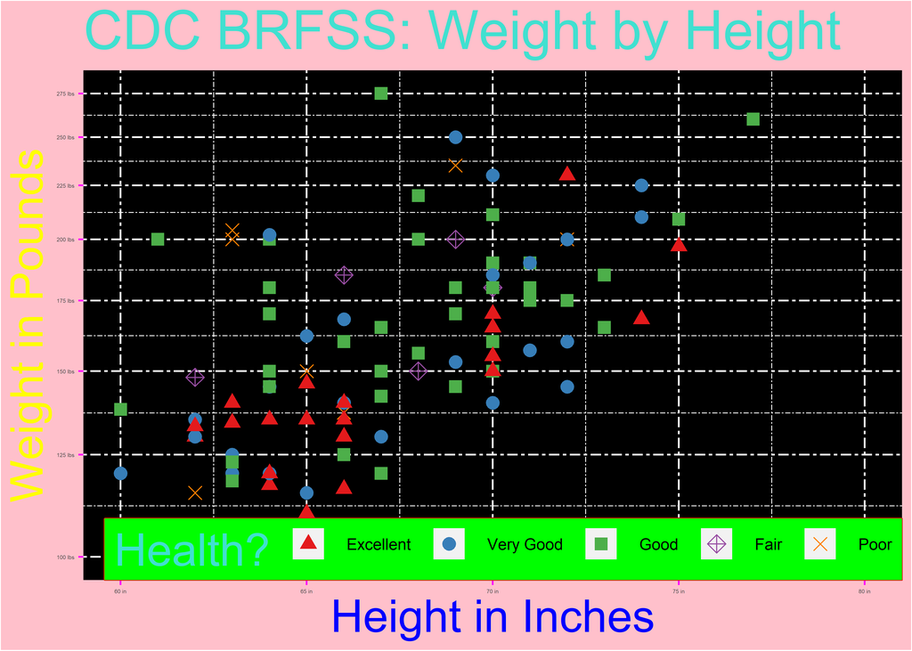

```r
ggplot(
  data = cdc_small,
  aes(x = height, y = weight)
) +
  geom_point(size = 3, aes(shape = genhlth, color = genhlth)) +
  scale_y_continuous(
    name = "Weight in Pounds",
    limits = c(100, 275),
    breaks = seq(100, 275, 25),
    trans = "log10",
    labels = scales::label_number(
      accuracy = 1,
      suffix = " lbs"
    )
  ) +
  scale_x_continuous(
    name = "Height in Inches",
    limits = c(60, 80),
    breaks = seq(60, 80, 5),
    labels = scales::label_number(accuracy = 1, suffix = " in")
  ) +
  scale_shape_manual(
    name = "Health?",
    labels = c(
      "Excellent", "Very Good",
      "Good", "Fair", "Poor"
    ),
    values = c(17, 19, 15, 9, 4)
  ) +
  scale_color_brewer(
    name = "Health?",
    labels = c(
      "Excellent", "Very Good",
      "Good", "Fair", "Poor"
    ),
    palette = "Set1"
  ) +
  theme(
    legend.position = c(1, 0),
    legend.justification = c(1, 0),

    legend.box.background = element_rect(fill = "white", color = "red"),
    plot.background = element_rect(fill = "pink"),
    legend.direction = "horizontal",
    legend.background = element_rect(fill = "green"),
    axis.title.x = element_text(color = "blue"),
    axis.title.y = element_text(color = "yellow"),
    axis.ticks = element_line(color = "magenta"),
    panel.grid = element_line(linetype = "twodash"),
    panel.background = element_rect(fill = "black"),
    title = element_text(color = "turquoise", size = 25),
    axis.text = element_text(size = 3)
  ) +
  labs(title = "CDC BRFSS: Weight by Height")
```

## Exercise 3

We will be making use of your code from Exercise 3 from *L07 Layers*. Using the `NU_admission_data.csv` you created two separate plots derived from the single plot depicted in `undergraduate-admissions-statistics.pdf`. Style these plots so they follow a “Northwestern” theme. You are welcome to display the plots separately OR design a layout that displays both together (likely one stacked above the other).

**Additional requirement:**

Use a free non-standard font from google for the title. Pick one that looks similar to a Northwestern font.

```r
# BARPLOT
bar_data <- nu_data %>%
  filter(year > 1999) %>%
  select(-contains("_rate")) %>%
  pivot_longer(
    cols = -year,
    names_to = "category",
    values_to = "count"
  )

#bar chart labels dataset
bar_label_data <- bar_data %>%
  mutate(col_label = prettyNum(count, big.mark = ","))

#barplot
barplot <- ggplot(bar_data, aes(x = year, y = count)) +
  geom_col(
    aes(fill = category),
    position = "identity",
    width = 0.6
    ) +
  geom_text(
    data = bar_label_data,
    aes(label = col_label),
    color = "white",
    size = 2,
    vjust = 1,
    nudge_y = -200
    ) +
  theme_classic() +
  scale_x_continuous(
    name = "Entering Year",
    breaks = 2000:2020,
    expand = c(0, 0.25)
    ) +
  scale_y_continuous(
    name = "Appllications",
    breaks = seq(0, 50000, 5000),
    labels = scales::label_comma(),
    limits = c(0, 45000),
    expand = c(0, 0)
    ) +
  scale_fill_manual(
    name = NULL,
    limits = c("applications", "admitted_students", "matriculants"),
    labels = c("Applicants   ", "Admitted students   ", "Matriculants"),
    values = c("#B6ACD1", "#836EAA", "#4E2A84")
    )

#LINE PLOT

#line plot dataset
line_data <- nu_data %>%
  filter(year > 1999) %>%
  select(year, admission_rate, yield_rate) %>%
  pivot_longer(
    cols = -year,
    names_to = "type",
    values_to = "rate")

#line plot labels dataset
line_label_data <- line_data %>%
  mutate(rate_labels = str_c(rate, "%"),
         label_y = case_when(
           type == "admission_rate" ~ rate - 2,
           type == "yield_rate" ~ rate + 2
           )
         )

#lineplot
lineplot <- ggplot(line_data, aes(x = year, y = rate)) +
  geom_line(
    aes(color = type)
    ) +
  geom_point(
    mapping = aes(shape = type, fill = type),
    color = "white"
    ) +
  theme_classic() +
  scale_x_continuous(
    name = "Entering Year",
    breaks = 2000:2020,
    expand = c(0, 0.35)
    ) +
  scale_y_continuous(
    name = "Rate",
    labels = scales::label_percent(scale = 1),
    limits = c(0, 60),
    breaks = seq(0, 60, 10),
    expand = c(0,0)
    ) +
  scale_shape_manual(
    name = NULL,
    values = c(21, 24),
    labels = c("Admission rate", "Yield rate"),
    ) +
  scale_color_manual(
    name = NULL,
    labels = c("Admission rate", "Yield rate"),
    values = c("#4E2A84", "#836EAA")
    ) +
  scale_fill_manual(
    name = NULL,
    labels = c("Admission rate", "Yield rate"),
    values = c("#4E2A84", "#836EAA")
    ) +
  geom_text(
    data = line_label_data,
    aes(y = label_y, label = rate_labels),
    size = 3
    )
```

```r
font_add_google("Merriweather" , "merriweather")
font_add_google("Roboto", "roboto")
showtext_auto()

barplot_mods <- barplot +
   theme(
    legend.justification = c(0.5, 0.5),
    legend.position = c(0.5, 0.9),
    legend.direction = "horizontal",
    plot.title = element_text(hjust = 0.5, family = "merriweather"),
    axis.title = element_text(family = "merriweather"),
    axis.text = element_text(family = "roboto"),
    legend.text = element_text(family = "merriweather")
    )

lineplot_mods <- lineplot +
  ggtitle("Northwestern University\nUndergraduate Admissions 2000-2020") +
  theme(
    legend.justification = c(0.5, 0.5),
    legend.position = c(0.5, 0.9),
    legend.direction = "horizontal",
    plot.title = element_text(hjust = 0.5, family = "merriweather"),
    axis.title = element_text(family = "merriweather"),
    axis.text = element_text(family = "roboto"),
    legend.text = element_text(family = "merriweather")
    )

lineplot_mods / barplot_mods
```

[figure not shown]